# Section Week 7 - Partial correlations, Practice with contrasts, 2x3 ANOVA, Contrasts by hand

## ## Quiz 2 Feedback

- Read questions carefully and give an attempted answer for every question
- Manage your time progressing through the quiz
- When testing something: 1). state the name of the test, 2). **Give formula or R command**, 3). Show your work, rather than just writing a number, so that in case you are wrong, we can still give lots of partial credit!
- Calculate statistic and critical value or p value
- Reject the null (or not)
- Informal conclusion
- When writing up results: 1). use a few numbers, *b = 3.21, t(23) = 2.42, p = 0.012*, 2). Formal words: There was a significant quadratic effect of smiling on creepiness 3). Informal words: Those who smile more tend to be less creepy, but there is a point at which smiling too much causes an increase in creepiness.

## Partial Correlations

Remember that both the **Baron & Kenny method** and a test for **partial correlation** can test causal hypotheses.

Let’s compare a test with partial correlation to mediation. Let’s quickly review our findings from the **coffee problem** from Homework 3.

**Causal Models**

**IV**: *Coffee* - 20 subjects in each group either had 0 cups, 2 cups, or 4 cups

**DV**: *Performance* - on a stats quiz with 10 problems, 5-89 points

**Possible Mediator 1**: *Number of problems attempted* (hyperactivity)

**Possible Mediator 2**: *Accuracy* - how likely they were to get a problem right if they tried (better success)

```r
d<-read.csv("http://www.stanford.edu/class/psych252/data/caffeine.csv")
str(d)
```

```
## 'data.frame':    62 obs. of  4 variables:
##  $ coffee : int  1 1 1 1 2 1 1 1 2 1 ...
##  $ perf   : int  53 9 31 38 40 40 9 37 62 23 ...
##  $ accur  : num  0.45 0.5 0.499 0.454 0.421 ...
##  $ numprob: int  7 6 6 7 8 6 6 8 7 7 ...
```

```r
d$cups = 0*as.numeric(d$coffee==1) + 2*as.numeric(d$coffee==2) + 4*as.numeric(d$coffee==3)
table(d$cups)
```

```
##
##  0  2  4
## 20 20 20
```

### Visualize your data!

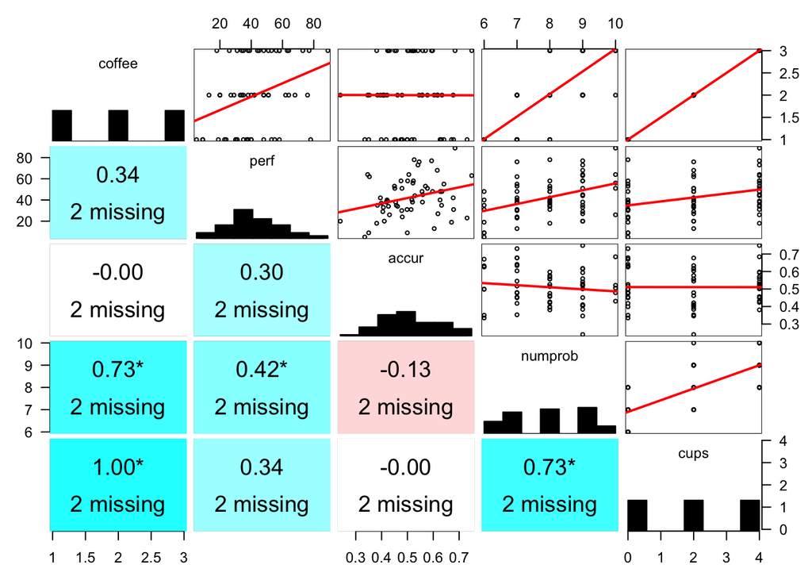

```r
library(gpairs)
gpairs(d, upper.pars = list(scatter = "lm",
                         conditional = "barcode",
                         mosaic = "mosaic"),
       lower.pars = list(scatter = "stats",
                         conditional = "boxplot",
                         mosaic = "mosaic"),
       stat.pars = list(fontsize = 14, signif = 0.05,
                        verbose = FALSE, use.color = TRUE,
                        missing = 'missing', just = 'centre'))
```

### Mediation

What’s the model we don’t need?: *Mediator predicting our DV on its own. Just ignore this guy.*

```r
with(d, summary(lm(perf~numprob)))
```

```
##
## Call:
## lm(formula = perf ~ numprob)
##
## Residuals:
##    Min     1Q Median     3Q    Max
## -29.66 -11.30  -0.17  10.28  39.79
##
## Coefficients:
##             Estimate Std. Error t value Pr(>|t|)
## (Intercept)    -9.17      14.84   -0.62  0.53898
## numprob         6.48       1.85    3.51  0.00087 ***
## ---
## Signif. codes:  0 '***' 0.001 '**' 0.01 '*' 0.05 '.' 0.1 ' ' 1
##
## Residual standard error: 16.8 on 58 degrees of freedom
##   (2 observations deleted due to missingness)
## Multiple R-squared:  0.175,  Adjusted R-squared:  0.161
## F-statistic: 12.3 on 1 and 58 DF,  p-value: 0.000872
```

```r
with(d, summary(lm(perf~cups))) #c
```

```
##
## Call:
## lm(formula = perf ~ cups)
##
## Residuals:
##    Min     1Q Median     3Q    Max
## -31.84 -11.85  -0.37   8.63  43.11
##
## Coefficients:
##             Estimate Std. Error t value Pr(>|t|)
## (Intercept)    34.89       3.56    9.80  6.4e-14 ***
## cups            3.74       1.38    2.71   0.0088 **
## ---
## Signif. codes:  0 '***' 0.001 '**' 0.01 '*' 0.05 '.' 0.1 ' ' 1
##
## Residual standard error: 17.4 on 58 degrees of freedom
##   (2 observations deleted due to missingness)
## Multiple R-squared:  0.112,  Adjusted R-squared:  0.0972
## F-statistic: 7.35 on 1 and 58 DF,  p-value: 0.0088
```

```r
with(d, summary(lm(numprob~cups))) #a
```

```
##
## Call:
## lm(formula = numprob ~ cups)
##
## Residuals:
##    Min     1Q Median     3Q    Max
##  -1.00  -0.90   0.05   1.00   2.05
##
## Coefficients:
##             Estimate Std. Error t value Pr(>|t|)
## (Intercept)   6.9000     0.1668   41.36  < 2e-16 ***
## cups          0.5250     0.0646    8.12  3.8e-11 ***
## ---
## Signif. codes:  0 '***' 0.001 '**' 0.01 '*' 0.05 '.' 0.1 ' ' 1
##
## Residual standard error: 0.817 on 58 degrees of freedom
##   (2 observations deleted due to missingness)
## Multiple R-squared:  0.532,  Adjusted R-squared:  0.524
## F-statistic:   66 on 1 and 58 DF,  p-value: 3.79e-11
```

```r
with(d, summary(lm(perf~cups+numprob))) #b and c'
```

```
##
## Call:
## lm(formula = perf ~ cups + numprob)
##
## Residuals:
##    Min     1Q Median     3Q    Max
## -29.60 -11.56  -0.13   9.26  39.10
##
## Coefficients:
##             Estimate Std. Error t value Pr(>|t|)
## (Intercept)   -4.843     19.087   -0.25    0.801
## cups           0.714      1.958    0.36    0.717
## numprob        5.759      2.721    2.12    0.039 *
## ---
## Signif. codes:  0 '***' 0.001 '**' 0.01 '*' 0.05 '.' 0.1 ' ' 1
##
## Residual standard error: 16.9 on 57 degrees of freedom
##   (2 observations deleted due to missingness)
## Multiple R-squared:  0.177,  Adjusted R-squared:  0.148
## F-statistic: 6.14 on 2 and 57 DF,  p-value: 0.00386
```

### Partial Correlation

Now let’s compare this test of our causal model with a partial correlation test. Partial correlations find the correlation between two variables after removing the effects of other variables.

x = **IV** *(cups of coffee)*

y = **DV** *(performance)*

z = **third variable** *(mediator)*

First, we’ll need to find out what our correlations are.

```r
a = with(d, cor.test(cups,perf)); print(a)
```

```
##
##  Pearson's product-moment correlation
##
## data:  cups and perf
## t = 2.711, df = 58, p-value = 0.0088
## alternative hypothesis: true correlation is not equal to 0
## 95 percent confidence interval:
##  0.08906 0.54307
## sample estimates:
##    cor
## 0.3354
```

```r
b = with(d, cor.test(cups,numprob)); print(b)
```

```
##
##  Pearson's product-moment correlation
##
## data:  cups and numprob
## t = 8.124, df = 58, p-value = 3.789e-11
## alternative hypothesis: true correlation is not equal to 0
## 95 percent confidence interval:
##  0.5838 0.8298
## sample estimates:
##    cor
## 0.7296
```

```r
c = with(d, cor.test(numprob,perf)); print(c)
```

```
##
##  Pearson's product-moment correlation
##
## data:  numprob and perf
## t = 3.511, df = 58, p-value = 0.0008722
## alternative hypothesis: true correlation is not equal to 0
## 95 percent confidence interval:
##  0.1843 0.6079
## sample estimates:
##    cor
## 0.4186
```

What’s the formula for a partial correlation?

$\textrm{Partial Correlation }: r(xy.z) = \frac{{r_{xy} - r_{xz} * r_{yz}}}{\sqrt{(1-r_{xz}^2) * (1-r_{yz}^2)}}$

```r
n <- 60
xy<- as.numeric(a$estimate)
xz<- as.numeric(b$estimate)
yz<- as.numeric(c$estimate)

r_xy_z<-(xy-(xz*yz))/(sqrt((1-xz^2)*(1-yz^2))); print(r_xy_z)
```

```
## [1] 0.04826
```

```r
t2 <- r_xy_z*sqrt((n-2)/(1-r_xy_z^2)); print(t2)
```

```
## [1] 0.368
```

```r
ptr<-pt(t2,n-2, lower.tail=FALSE); print(ptr)
```

```
## [1] 0.3571
```

Now let’s try wth accuracy, which we know isn’t a mediator!

Cups of Coffee $\leadsto$ Accuracy $\longrightarrow$ Performance

Quick review of what we found last time:

```r
with(d, summary(lm(perf~cups))) #c
```

```
##
## Call:
## lm(formula = perf ~ cups)
##
## Residuals:
##    Min     1Q Median     3Q    Max
## -31.84 -11.85  -0.37   8.63  43.11
##
## Coefficients:
##             Estimate Std. Error t value Pr(>|t|)
## (Intercept)    34.89       3.56    9.80  6.4e-14 ***
## cups            3.74       1.38    2.71   0.0088 **
## ---
## Signif. codes:  0 '***' 0.001 '**' 0.01 '*' 0.05 '.' 0.1 ' ' 1
##
## Residual standard error: 17.4 on 58 degrees of freedom
##   (2 observations deleted due to missingness)
## Multiple R-squared:  0.112,  Adjusted R-squared:  0.0972
## F-statistic: 7.35 on 1 and 58 DF,  p-value: 0.0088
```

```r
with(d, summary(lm(accur~cups))) #a
```

```
##
## Call:
## lm(formula = accur ~ cups)
##
## Residuals:
##      Min       1Q   Median       3Q      Max
## -0.27062 -0.08471 -0.00076  0.08388  0.23812
##
## Coefficients:
##              Estimate Std. Error t value Pr(>|t|)
## (Intercept)  0.511140   0.022174   23.05   <2e-16 ***
## cups        -0.000143   0.008588   -0.02     0.99
## ---
## Signif. codes:  0 '***' 0.001 '**' 0.01 '*' 0.05 '.' 0.1 ' ' 1
##
## Residual standard error: 0.109 on 58 degrees of freedom
##   (2 observations deleted due to missingness)
## Multiple R-squared:  4.77e-06,   Adjusted R-squared:  -0.0172
## F-statistic: 0.000277 on 1 and 58 DF,  p-value: 0.987
```

```r
with(d, summary(lm(perf~cups+accur))) #b and c'
```

```
##
## Call:
## lm(formula = perf ~ cups + accur)
##
## Residuals:
##    Min     1Q Median     3Q    Max
## -34.08  -9.88  -0.83   7.82  42.35
##
## Coefficients:
##             Estimate Std. Error t value Pr(>|t|)
## (Intercept)     8.93      10.86    0.82   0.4144
## cups            3.74       1.32    2.84   0.0063 **
## accur          50.80      20.17    2.52   0.0146 *
## ---
## Signif. codes:  0 '***' 0.001 '**' 0.01 '*' 0.05 '.' 0.1 ' ' 1
##
## Residual standard error: 16.7 on 57 degrees of freedom
##   (2 observations deleted due to missingness)
## Multiple R-squared:  0.201,  Adjusted R-squared:  0.173
## F-statistic: 7.19 on 2 and 57 DF,  p-value: 0.00165
```

```r
a = with(d, cor.test(cups,perf)); print(a)
```

```
##
##  Pearson's product-moment correlation
##
## data:  cups and perf
## t = 2.711, df = 58, p-value = 0.0088
## alternative hypothesis: true correlation is not equal to 0
## 95 percent confidence interval:
##  0.08906 0.54307
## sample estimates:
##    cor
## 0.3354
```

```r
b = with(d, cor.test(cups,accur)); print(b)
```

```
##
##  Pearson's product-moment correlation
##
## data:  cups and accur
## t = -0.0166, df = 58, p-value = 0.9868
## alternative hypothesis: true correlation is not equal to 0
## 95 percent confidence interval:
##  -0.2560  0.2519
## sample estimates:
##       cor
## -0.002184
```

```r
c = with(d, cor.test(accur,perf)); print(c)
```

```
##
##  Pearson's product-moment correlation
##
## data:  accur and perf
## t = 2.373, df = 58, p-value = 0.021
## alternative hypothesis: true correlation is not equal to 0
## 95 percent confidence interval:
##  0.04706 0.51264
## sample estimates:
##    cor
## 0.2974
```

```r
n <- 60
xy<- as.numeric(a$estimate)
xz<- as.numeric(b$estimate)
yz<- as.numeric(c$estimate)

r_xy_z<-(xy-(xz*yz))/(sqrt((1-xz^2)*(1-yz^2))); print(r_xy_z)
```

```
## [1] 0.352
```

```r
t2 <- r_xy_z*sqrt((n-2)/(1-r_xy_z^2)); print(t2)
```

```
## [1] 2.864
```

```r
ptr<-pt(t2,n-2,lower.tail=FALSE); print(ptr)
```

```
## [1] 0.002908
```

### Partial Mediation w/`psych`: `partial.r()`

```r
library(psych)
?partial.r
```

For number of problems attempted:

```r
da = subset(d,select=c('cups','perf','numprob'))
partial.r(da, 1:2, 3)
```

```
## partial correlations
##      cups perf
## cups 1.00 0.05
## perf 0.05 1.00
```

For accuracy:

```r
da1 = subset(d,select=c('cups','perf','accur'))
partial.r(da1, 1:2, 3)
```

```
## partial correlations
##      cups perf
## cups 1.00 0.35
## perf 0.35 1.00
```

So far, we’ve considered causal models like this: What if cups of coffee predicted both the number of problems attempted and performance, but performance and the number of problems weren’t related?

So instead of this model:

#### Cups of Coffee $\longrightarrow$ Hyperactivity $\longrightarrow$ Performance

We were interested in this model:

#### Cups of Coffee $\longrightarrow$ Hyperactivity

$\downarrow$

#### Performance

```r
n <- 60
xy<- .26
xz<- .32
yz<- .03

r_xy_z<-(xy-(xz*yz))/(sqrt((1-xz^2)*(1-yz^2))); print(r_xy_z)
```

```
## [1] 0.2644
```

```r
t2 <- r_xy_z*sqrt((n-2)/(1-r_xy_z^2)); print(t2)
```

```
## [1] 2.088
```

```r
ptr<-pt(t2,n-2, lower.tail=FALSE); print(ptr)
```

```
## [1] 0.0206
```

## Practice with Contrasts

Let’s practice interpreting contrasts!

Remember our handy function from last time to test for **orthogonality**?

```r
c_orth_4 <- function(x) {
  a <- (x[1,1]*x[1,2])+(x[2,1]*x[2,2])+(x[3,1]*x[3,2])+(x[4,1]*x[4,2]);
  b <- (x[1,2]*x[1,3])+(x[2,2]*x[2,3])+(x[3,2]*x[3,3])+(x[4,2]*x[4,3]);
  c <- (x[1,1]*x[1,3])+(x[2,1]*x[2,3])+(x[3,1]*x[3,3])+(x[4,1]*x[4,3]);
  d <- cbind(a,b,c); rownames(d)=c('Contrasts'); print(d)
  e <- a+b+c; names(e)=c('Sum'); print(e) }
```

Orthogonal contrasts possible for 4 groups! *Remember that you can have k-1 contrasts, if k is the number of groups that you have*

There are three different sets of orthogonal contrasts that are useful for comparing 4 different groups. These are useful in different situations. Let’s consider a series of experiments where we’re interested in what predicts whether a grad student is willing to register early for a conference. What do each of these sets of contrasts test?

### When our IV is quantitative:

For instance, let’s say that we’re looking at level of trait anxiety on likelihood of reigstering early for a conference.

```r
c1 <- cbind(c(-3,-1,1,3), c(1,-1,-1,1), c(-1,3,-3,1)); c_orth_4(c1)
```

```
##           a b c
## Contrasts 0 0 0
## Sum
##   0
```

```r
rownames(c1) <- c(1,2,3,4); print(c1)
```

```
##   [,1] [,2] [,3]
## 1   -3    1   -1
## 2   -1   -1    3
## 3    1   -1   -3
## 4    3    1    1
```

### When we have two levels of one factor, and two levels of another factor.

Let’s say that Factor A is fee for late registration (low vs. high) and Factor B is the number of days before the deadline a warning is issued (one week vs. 1 day) on likelihood of early registration

```r
c2 <- cbind(c(1,1,-1,-1), c(1,-1,0,0), c(0,0,1,-1)); c_orth_4(c2)
```

```
##           a b c
## Contrasts 0 0 0
## Sum
##   0
```

```r
rownames(c2) <- c('reg1','reg2','days1','days2'); print(c2)
```

```
##       [,1] [,2] [,3]
## reg1     1    1    0
## reg2     1   -1    0
## days1   -1    0    1
## days2   -1    0   -1
```

### When we’re using a 2x2 factorial design:

Again, let’s say that Factor A is gender (male vs. female) and Factor B is framing of an issue (loss vs. gain) on likelihood of early registration

```r
c3 <- cbind(c(-1,1,-1,1), c(-1,-1,1,1), c(1,-1,-1,1)); c_orth_4(c3)
```

```
##           a b c
## Contrasts 0 0 0
## Sum
##   0
```

```r
rownames(c3) <- c('men/loss','women/loss','men/gain','women/gain'); print(c3)
```

```
##            [,1] [,2] [,3]
## men/loss     -1   -1    1
## women/loss    1   -1   -1
## men/gain     -1    1   -1
## women/gain    1    1    1
```

## Visualizing our design matrix

Load in some data

```r
d0 = read.csv("http://www.stanford.edu/class/psych252/data/lifesatis.csv")
str(d0)
```

```
## 'data.frame':    62 obs. of  6 variables:
##  $ id      : int  1 2 3 4 5 6 7 8 9 10 ...
##  $ age     : num  36 41.8 60 23.8 48 ...
##  $ kids    : int  0 1 0 0 1 0 5 0 0 0 ...
##  $ jobsatis: int  3 4 3 3 4 3 3 4 3 2 ...
##  $ marsatis: int  4 1 4 1 5 6 3 1 2 7 ...
##  $ lifsatis: int  4 1 3 2 4 4 4 4 2 4 ...
```

```r
d0$kids_cat[d0$kids < 1] = 'None'
d0$kids_cat[d0$kids == 1] = 'One'
d0$kids_cat[d0$kids > 1] = 'Multiple'

d0$kids_cat = factor(d0$kids_cat)
str(d0)
```

```
## 'data.frame':    62 obs. of  7 variables:
##  $ id      : int  1 2 3 4 5 6 7 8 9 10 ...
##  $ age     : num  36 41.8 60 23.8 48 ...
##  $ kids    : int  0 1 0 0 1 0 5 0 0 0 ...
##  $ jobsatis: int  3 4 3 3 4 3 3 4 3 2 ...
##  $ marsatis: int  4 1 4 1 5 6 3 1 2 7 ...
##  $ lifsatis: int  4 1 3 2 4 4 4 4 2 4 ...
##  $ kids_cat: Factor w/ 3 levels "Multiple","None",..: 2 3 2 2 3 2 1 2 2 2 ...
```

### Visualize the data

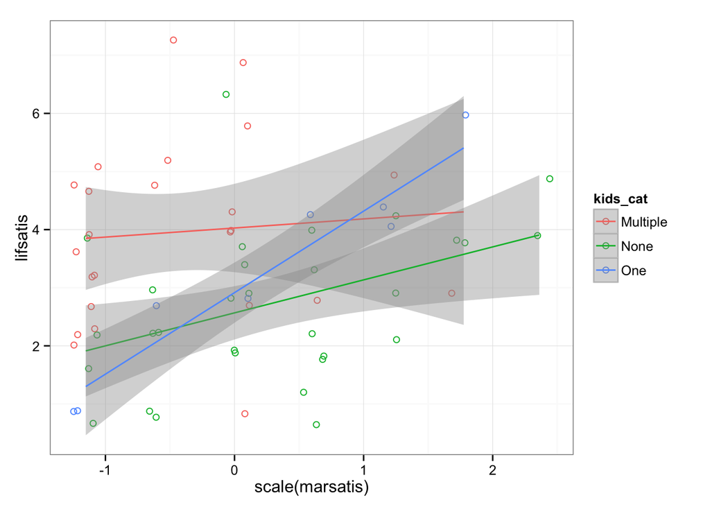

```r
library(ggplot2)
ggplot(d0,
       aes(x=scale(marsatis),
           y=lifsatis, color=kids_cat)) +
  geom_point(shape=1, position=position_jitter(width=.1)) +
  geom_smooth(method=lm, se=TRUE) +
  theme_bw()
```

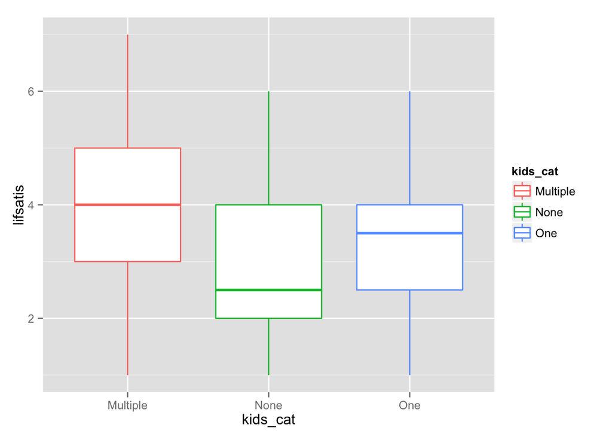

```r
ggplot(d0, aes(kids_cat, lifsatis, color=kids_cat)) +
  geom_boxplot()
```

### View the design matrix

First let’s set up some contrasts and see what the `lm()` output looks like:

```r
levels(d0$kids_cat)
```

```
## [1] "Multiple" "None"     "One"
```

```r
contrasts(d0$kids_cat) = cbind(c(1, -2, 1), c(1, 0, -1))

# orthogonal?
apply(contrasts(d0$kids_cat), 2, sum)
```

```
## [1] 0 0
```

```r
colnames(contrasts(d0$kids_cat)) = c('kids-vs-none', 'multiple-vs-one')
contrasts(d0$kids_cat)
```

```
##          kids-vs-none multiple-vs-one
## Multiple            1               1
## None               -2               0
## One                 1              -1
```

```r
lm1 = lm(lifsatis~kids_cat, data=d0); summary(lm1)
```

```
##
## Call:
## lm(formula = lifsatis ~ kids_cat, data = d0)
##
## Residuals:
##    Min     1Q Median     3Q    Max
## -2.958 -0.958  0.042  1.042  3.267
##
## Coefficients:
##                         Estimate Std. Error t value Pr(>|t|)
## (Intercept)                3.314      0.215   15.44   <2e-16 ***
## kids_catkids-vs-none       0.290      0.131    2.21    0.031 *
## kids_catmultiple-vs-one    0.354      0.294    1.20    0.233
## ---
## Signif. codes:  0 '***' 0.001 '**' 0.01 '*' 0.05 '.' 0.1 ' ' 1
##
## Residual standard error: 1.44 on 59 degrees of freedom
## Multiple R-squared:  0.141,  Adjusted R-squared:  0.111
## F-statistic: 4.83 on 2 and 59 DF,  p-value: 0.0114
```

Now, let’s visualize our design matrix:

```r
m1 <- model.matrix(lm1); head(m1)
```

```
##   (Intercept) kids_catkids-vs-none kids_catmultiple-vs-one
## 1           1                   -2                       0
## 2           1                    1                      -1
## 3           1                   -2                       0
## 4           1                   -2                       0
## 5           1                    1                      -1
## 6           1                   -2                       0
```

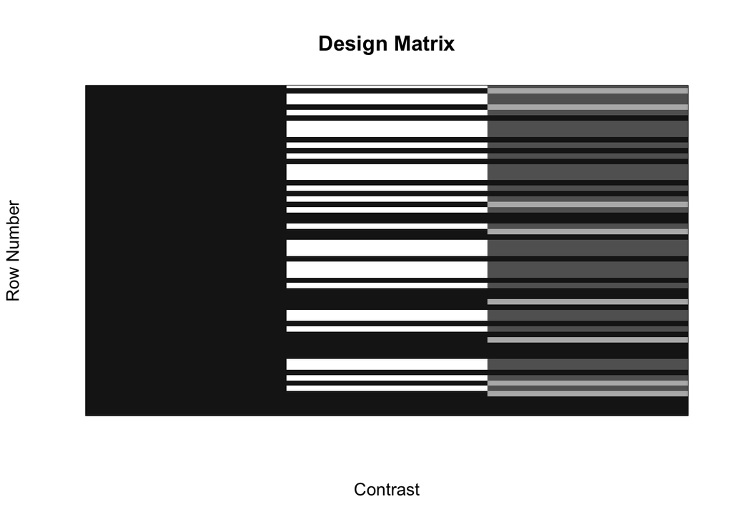

```r
library(gplots) # to use the colorpanel() function
# plot design matrix for intercept + 2 contrasts
image(t(m1), axes=FALSE, frame.plot=TRUE, col=colorpanel(20, "white", "grey10"), main="Design Matrix", ylim=c(1, 0), ylab='Row Number', xlab='Contrast')
```

```r
# add lifsatis data to matrix
m1 = cbind(m1,as.matrix(d0$lifsatis)); head(m1)
```

```
##   (Intercept) kids_catkids-vs-none kids_catmultiple-vs-one
## 1           1                   -2                       0 4
## 2           1                    1                      -1 1
## 3           1                   -2                       0 3
## 4           1                   -2                       0 2
## 5           1                    1                      -1 4
## 6           1                   -2                       0 4
```

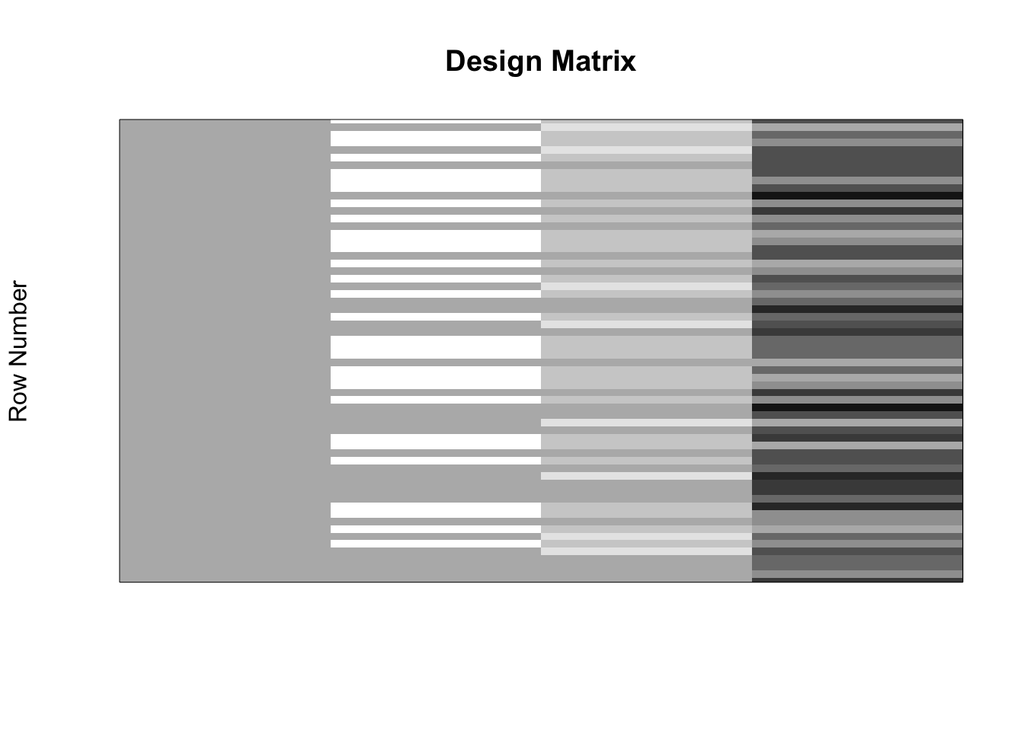

```r
# plot design matrix w/lifsatis data in last column
image(t(m1), axes=FALSE, frame.plot=TRUE, col=colorpanel(20, "white", "grey10"), main="Design Matrix", ylim=c(1, 0), ylab='Row Number')
```

## Calculate the significance of a contrast by hand!

First let’s get some stats:

```r
# some stats
k = 3 # number groups
means = aggregate(lifsatis~kids_cat,data=d0,function(x) mean(x)); means
```

```
##   kids_cat lifsatis
## 1 Multiple    3.958
## 2     None    2.733
## 3      One    3.250
```

```r
ns = aggregate(lifsatis~kids_cat,data=d0,function(x) length(x)); ns
```

```
##   kids_cat lifsatis
## 1 Multiple       24
## 2     None       30
## 3      One        8
```

```r
N = sum(ns[,2]) # total participants
sems = aggregate(lifsatis~kids_cat, data=d0, function(x) (sd(x) / sqrt(length(x)))); sems
```

```
##   kids_cat lifsatis
## 1 Multiple   0.3155
## 2     None   0.2346
## 3      One   0.5901
```

```r
vars = aggregate(lifsatis~kids_cat, data=d0, function(x) (var(x))); vars
```

```
##   kids_cat lifsatis
## 1 Multiple    2.389
## 2     None    1.651
## 3      One    2.786
```

```r
grand_mean = mean(d0$lifsatis); grand_mean
```

```
## [1] 3.274
```

```r
mean_ofmeans = mean(means[,2]); mean_ofmeans
```

```
## [1] 3.314
```

```r
# compare intercept to both means!
summary(lm1)
```

```
##
## Call:
## lm(formula = lifsatis ~ kids_cat, data = d0)
##
## Residuals:
##    Min     1Q Median     3Q    Max
## -2.958 -0.958  0.042  1.042  3.267
##
## Coefficients:
##                         Estimate Std. Error t value Pr(>|t|)
## (Intercept)                3.314      0.215   15.44   <2e-16 ***
## kids_catkids-vs-none       0.290      0.131    2.21    0.031 *
## kids_catmultiple-vs-one    0.354      0.294    1.20    0.233
## ---
## Signif. codes:  0 '***' 0.001 '**' 0.01 '*' 0.05 '.' 0.1 ' ' 1
##
## Residual standard error: 1.44 on 59 degrees of freedom
## Multiple R-squared:  0.141,  Adjusted R-squared:  0.111
## F-statistic: 4.83 on 2 and 59 DF,  p-value: 0.0114
```

Let’s test our first contrast (whether having any kids improves life satisfaction).

```r
# pull out our contrast, and multiply each contrast by the group means
contrast1 = contrasts(d0$kids_cat)[,1]; contrast1
```

```
## Multiple     None      One
##        1       -2        1
```

```r
l1 = contrast1 * means[,2]; l1
```

```
## Multiple     None      One
##    3.958   -5.467    3.250
```

```r
l1 = sum(l1); l1
```

```
## [1] 1.742
```

```r
# some more stats
T = sum(ns[,2]*means[,2]); T
```

```
## [1] 203
```

```r
C_val = (T^2)/N; C_val
```

```
## [1] 664.7
```

```r
SSj = (ns[,2]-1)*vars[,2]; SSj
```

```
## [1] 54.96 47.87 19.50
```

```r
SSerror = sum(SSj); SSerror
```

```
## [1] 122.3
```

```r
MSerror = SSerror/(N-k); MSerror
```

```
## [1] 2.073
```

```r
# compare error to anova table from lm output
anova(lm1)
```

```
## Analysis of Variance Table
##
## Response: lifsatis
##           Df Sum Sq Mean Sq F value Pr(>F)
## kids_cat   2     20   10.01    4.83  0.011 *
## Residuals 59    122    2.07
## ---
## Signif. codes:  0 '***' 0.001 '**' 0.01 '*' 0.05 '.' 0.1 ' ' 1
```

```r
# some extra values..
SSgroup = sum(((ns[,2]*means[,2])^2)/ns[,2]) - C_val; SSgroup
```

```
## [1] 20.01
```

```r
MSgroup = SSgroup/(k-1); MSgroup
```

```
## [1] 10.01
```

```r
Fstat = MSgroup/MSerror; Fstat
```

```
## [1] 4.827
```

```r
# Calculate t-stat for contrast
contrast1^2
```

```
## Multiple     None      One
##        1        4        1
```

```r
(contrast1^2)/ns[,2]
```

```
## Multiple     None      One
##  0.04167  0.13333  0.12500
```

```r
se2 = MSerror * sum((contrast1^2)/ns[,2]); se2
```

```
## [1] 0.622
```

```r
t_stat = l1/sqrt(se2); t_stat
```

```
## [1] 2.208
```

```r
p_val = 2*pt(t_stat, df=N-k, lower.tail=FALSE); p_val
```

```
## [1] 0.03112
```

```r
cat("t (", N-k,") = ", t_stat, ", p = ", p_val)
```

```
## t ( 59 ) =  2.208 , p =  0.03112
```

```r
# compare to lm output
summary(lm1)
```

```
##
## Call:
## lm(formula = lifsatis ~ kids_cat, data = d0)
##
## Residuals:
##    Min     1Q Median     3Q    Max
## -2.958 -0.958  0.042  1.042  3.267
##
## Coefficients:
##                         Estimate Std. Error t value Pr(>|t|)
## (Intercept)                3.314      0.215   15.44   <2e-16 ***
## kids_catkids-vs-none       0.290      0.131    2.21    0.031 *
## kids_catmultiple-vs-one    0.354      0.294    1.20    0.233
## ---
## Signif. codes:  0 '***' 0.001 '**' 0.01 '*' 0.05 '.' 0.1 ' ' 1
##
## Residual standard error: 1.44 on 59 degrees of freedom
## Multiple R-squared:  0.141,  Adjusted R-squared:  0.111
## F-statistic: 4.83 on 2 and 59 DF,  p-value: 0.0114
```